# Session 4 Example

## Preparation

In this tutorial we will be using the [cmdstanr](https://mc-stan.org/cmdstanr/articles/cmdstanr.html) R interface to CmdStan and the [bayesplot](https://mc-stan.org/bayesplot/articles/graphical-ppcs.html) package for our graphical model checking:

```r
library(cmdstanr)
library(posterior)
library(bayesplot)
library(ggplot2)
library(dplyr)
```

## Epilepsy RCT Model Expansion

For this example, we are analysing the results of a randomised controlled trial for a new epilepsy treatment. To briefly summarise our data:

- 59 participants randomised to either treatment or control
- 5 assessments (baseline + 4 follow-ups)
- Outcome is the number of seizures experienced

### Data

Let’s load our dataset and look at the general structure:

```r
data(epilepsy, package="brms")
head(epilepsy)
```

```
  Age Base Trt patient visit count obs       zAge      zBase
1  31   11   0       1     1     5   1  0.4249950 -0.7571728
2  30   11   0       2     1     3   2  0.2652835 -0.7571728
3  25    6   0       3     1     2   3 -0.5332740 -0.9444033
4  36    8   0       4     1     4   4  1.2235525 -0.8695111
5  22   66   0       5     1     7   5 -1.0124085  1.3023626
6  29   27   0       6     1     5   6  0.1055720 -0.1580352
```

Note that the continuous covariates have been standardised to simplify prior specification - this might not always be appropriate!

### Initial Model

What do we believe will be related to the seizure counts in our trial?

- Treatment or Control group
- Time since beginning treatment
  - Different between treatment & control
- Baseline number of seizures
- Age of participant

In R formula notation:

```
count ~ Trt + visit + Trt*visit + zBase + zAge
```

```r
epilepsy_prep <- epilepsy |>
  mutate(Trt = as.numeric(Trt) - 1,
         visit = as.numeric(visit) - 1,
         treat_x_visit = Trt * visit)
```

```r
epilepsy_standata <- list(
  N = length(unique(epilepsy_prep$patient)),
  T = length(unique(epilepsy_prep$visit)),
  K = 5,
  ID = epilepsy_prep$patient,
  x = epilepsy_prep[,c("Trt", "visit", "treat_x_visit", "zAge", "zBase")],
  seizures = epilepsy_prep$count
)
```

#### Outcome Family

Given that we are modelling counts, a Poisson is a good start. When using a Poisson outcome in a General Linear Model (GLM), we commonly use a log link function:

$$\displaylines{
y_i \sim Poisson(\lambda_i) \\
\lambda_i = \exp(\alpha + x_i^T\beta)
}$$

#### Priors

We will use weakly-informative priors (regularise our estimates to feasible/possible values). Because the intercept and coefficients are on the log-scale, the interpretation and choice of priors is slightly different

#### Stan Model

We’ve decided to use a Poisson Generalised Linear Model with a log-link as our initial attempt for modelling the data:

$$\displaylines{
y_i \sim Poisson(\lambda_i) \\
\lambda_i = \exp(\alpha + x_i^T\beta) \\
\alpha \sim N(0,5) \\
\beta_{1:5} \sim N(0,1)
}$$

Let’s have a look at how we would specify this in Stan:

```stan
data {
  int N;
  int T;
  int K;
  array[N*T] int ID;
  matrix[N*T, K] x;
  array[N*T] int seizures;
}

parameters {
  real alpha;
  vector[K] beta;
}

transformed parameters {
  vector[N*T] lambda = alpha + x * beta;
}

model {
  alpha ~ normal(0, 5);
  beta ~ std_normal();
  seizures ~ poisson_log(lambda);
}

generated quantities {
  array[N*T] int ypred = poisson_log_rng(lambda);
  vector[N*T] log_lik;
  for (nt in 1:(N*T)) {
    log_lik[nt] = poisson_log_lpmf(seizures[nt] | lambda[nt]);
  }
}
```

```r
poisson_fit <- poisson_mod$sample(
  data = epilepsy_standata,
  parallel_chains = 4,
  refresh = 0,
  show_messages = FALSE,
  show_exceptions = FALSE,
  seed = 2024
)
```

To inspect our estimates, we’ll first rename and transform them back to the interpretable scale (exponentiating):

```r
poisson_fit$draws() |>
    mutate_variables(intercept = exp(alpha),
                     b_treat = exp(`beta[1]`),
                     b_visit = exp(`beta[2]`),
                     b_treat_x_visit = exp(`beta[3]`),
                     b_zAge = exp(`beta[4]`),
                     b_zBase = exp(`beta[5]`)) |>
    subset_draws(variable=c("intercept", "b_treat", "b_visit", "b_treat_x_visit", "b_zAge", "b_zBase")) |>
    summarise_draws()
```

```
# A tibble: 6 × 10
  variable         mean median     sd    mad    q5   q95  rhat ess_bulk ess_tail
  <chr>           <dbl>  <dbl>  <dbl>  <dbl> <dbl> <dbl> <dbl>    <dbl>    <dbl>
1 intercept       7.23   7.22  0.394  0.398  6.61   7.89  1.00    1653.    2045.
2 b_treat         0.900  0.898 0.0659 0.0659 0.796  1.01  1.00    1600.    2053.
3 b_visit         0.957  0.956 0.0275 0.0272 0.913  1.00  1.00    1794.    2191.
4 b_treat_x_visit 0.972  0.970 0.0388 0.0383 0.911  1.04  1.00    1634.    2145.
5 b_zAge          1.15   1.15  0.0286 0.0278 1.11   1.20  1.00    3037.    2596.
6 b_zBase         1.83   1.83  0.0247 0.0245 1.79   1.87  1.00    2671.    2349.
```

We can see that all R-hats and ESS are within acceptable ranges. Next, we check the posterior-predictives for any obvious issues:

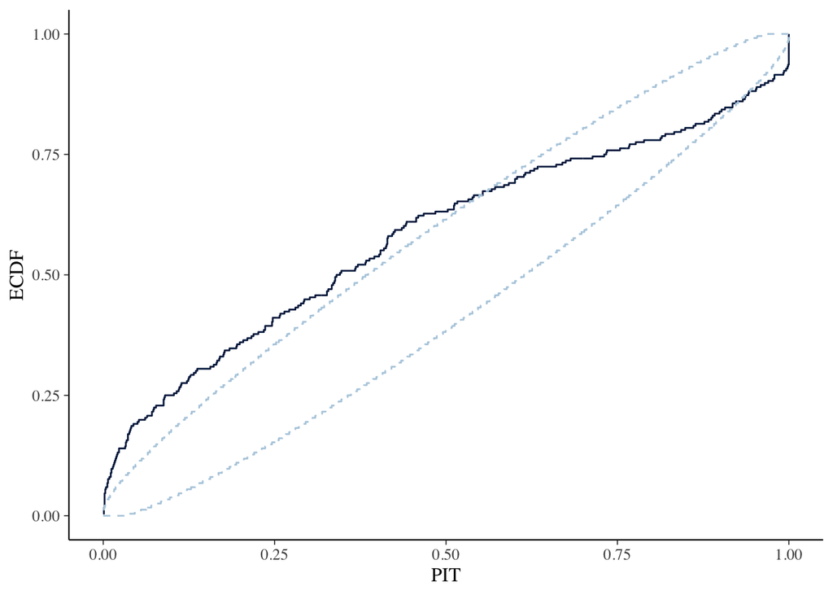

```r
ppc_pit_ecdf(y = epilepsy_standata$seizures,
                 poisson_fit$draws("ypred", format = "draws_matrix"))
```

We can see that the model is clearly inappropriate for the current dataset.

### Random-Effects Model (Normal)

We’ll add a random intercept for each individual, to relax the assumption of equal mean and variance in the Poisson. This also helps account for the non-independence of the observations - there are repeated measurements for the same individual:

$$\displaylines{
y_i \sim Poisson(\lambda_i) \\
\lambda_i = \exp(\alpha + x_i^T\beta + u_i) \\
\alpha \sim N(0,5) \\
\beta_{1:5} \sim N(0,1) \\
u_i \sim N(0,\sigma) \\
\sigma \sim Cauchy^+(0,5)
}$$

```stan
data {
  int N;
  int T;
  int K;
  array[N*T] int ID;
  matrix[N*T, K] x;
  array[N*T] int seizures;
}

parameters {
  real alpha;
  vector[K] beta;
  real<lower=0> u_sd;
  vector[N] u;
}

transformed parameters {
  vector[N*T] lambda = u[ID] + alpha + x * beta;
}

model {
  alpha ~ normal(0, 5);
  beta ~ std_normal();
  u_sd ~ cauchy(0, 5);
  u ~ normal(0, u_sd);
  seizures ~ poisson_log(lambda);
}

generated quantities {
  array[N*T] int ypred = poisson_log_rng(lambda);
  vector[N*T] log_lik;
  for (nt in 1:(N*T)) {
    log_lik[nt] = poisson_log_lpmf(seizures[nt] | lambda[nt]);
  }
}
```

```r
poisson_ranef_fit <- poisson_ranef_mod$sample(
  data = epilepsy_standata,
  parallel_chains = 4,
  refresh = 0,
  show_messages = FALSE,
  show_exceptions = FALSE,
  seed = 2024
)
```

We can see again that the Rhats & ESS are still acceptable (slightly worse ESS, but we’ll get to that!), but the posterior-predictive check is much better.

```r
poisson_ranef_fit$draws() |>
    mutate_variables(intercept = exp(alpha),
                     b_treat = exp(`beta[1]`),
                     b_visit = exp(`beta[2]`),
                     b_treat_x_visit = exp(`beta[3]`),
                     b_zAge = exp(`beta[4]`),
                     b_zBase = exp(`beta[5]`)) |>
    subset_draws(variable=c("intercept", "b_treat", "b_visit", "b_treat_x_visit", "b_zAge", "b_zBase")) |>
    summarise_draws()
```

```
# A tibble: 6 × 10
  variable         mean median     sd    mad    q5   q95  rhat ess_bulk ess_tail
  <chr>           <dbl>  <dbl>  <dbl>  <dbl> <dbl> <dbl> <dbl>    <dbl>    <dbl>
1 intercept       6.30   6.27  0.776  0.781  5.10   7.62  1.00     812.    1312.
2 b_treat         0.818  0.808 0.140  0.137  0.609  1.06  1.00     767.    1425.
3 b_visit         0.958  0.957 0.0275 0.0270 0.913  1.00  1.00    2191.    2636.
4 b_treat_x_visit 0.970  0.970 0.0393 0.0394 0.907  1.03  1.00    2210.    2657.
5 b_zAge          1.09   1.09  0.0886 0.0891 0.950  1.24  1.00     743.    1458.
6 b_zBase         2.07   2.06  0.165  0.159  1.82   2.35  1.00     810.    1445.
```

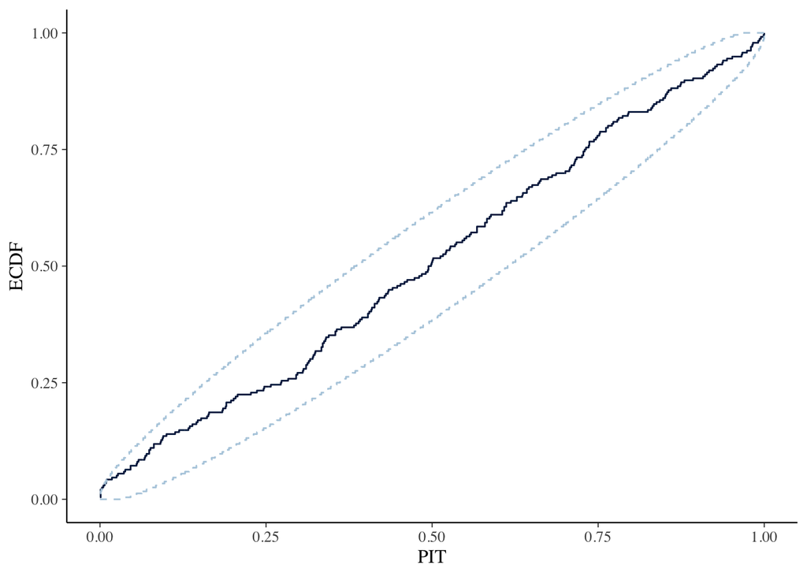

```r
ppc_pit_ecdf(y = epilepsy_standata$seizures,
                 poisson_ranef_fit$draws("ypred", format = "draws_matrix"))
```

The model is now better able to represent the observed data, but we are now estimating an additional $N$ parameters and the lower ESS indicates poorer exploration.

What can we do about this?

### Random-Effects Model (Gamma)

Let’s change our normally-distributed random effect to a Gamma with equal shape and rate parameters:

$$\displaylines{
y_i \sim Poisson(\lambda_i) \\
\lambda_i = \exp(\alpha + x_i^T\beta + u_i) \\
\alpha \sim N(0,5) \\
\beta_{1:5} \sim N(0,1) \\
\theta_i \sim Gamma(\phi,\phi) \\
\phi \sim Cauchy^+(0,5)
}$$

```stan
data {
  int N;
  int T;
  int K;
  array[N*T] int ID;
  matrix[N*T, K] x;
  array[N*T] int seizures;
}

parameters {
  real alpha;
  vector[K] beta;
  real<lower=0> u_shape;
  vector<lower=0>[N] u;
}

transformed parameters {
  vector[N*T] lambda = log(u[ID]) + alpha + x * beta;
}

model {
  alpha ~ normal(0, 5);
  beta ~ std_normal();
  u_shape ~ cauchy(0, 5);
  u ~ gamma(u_shape, u_shape);
  seizures ~ poisson_log(lambda);
}

generated quantities {
  array[N*T] int ypred = poisson_log_rng(lambda);
  vector[N*T] log_lik;
  for (nt in 1:(N*T)) {
    log_lik[nt] = poisson_log_lpmf(seizures[nt] | lambda[nt]);
  }
}
```

```r
poisson_gamma_fit <- poisson_gamma_mod$sample(
  data = epilepsy_standata,
  parallel_chains = 4,
  refresh = 0,
  show_messages = FALSE,
  show_exceptions = FALSE,
  seed = 2024
)
```

```r
poisson_gamma_fit$draws() |>
    mutate_variables(intercept = exp(alpha),
                     b_treat = exp(`beta[1]`),
                     b_visit = exp(`beta[2]`),
                     b_treat_x_visit = exp(`beta[3]`),
                     b_zAge = exp(`beta[4]`),
                     b_zBase = exp(`beta[5]`)) |>
    subset_draws(variable=c("intercept", "b_treat", "b_visit", "b_treat_x_visit", "b_zAge", "b_zBase")) |>
    summarise_draws()
```

```
# A tibble: 6 × 10
  variable         mean median     sd    mad    q5   q95  rhat ess_bulk ess_tail
  <chr>           <dbl>  <dbl>  <dbl>  <dbl> <dbl> <dbl> <dbl>    <dbl>    <dbl>
1 intercept       7.12   7.08  0.850  0.836  5.83   8.58  1.00     718.    1403.
2 b_treat         0.876  0.864 0.147  0.136  0.659  1.14  1.00     727.    1271.
3 b_visit         0.958  0.957 0.0277 0.0282 0.913  1.00  1.00    2440.    2900.
4 b_treat_x_visit 0.971  0.970 0.0391 0.0392 0.907  1.04  1.00    2285.    2832.
5 b_zAge          1.11   1.11  0.0929 0.0895 0.969  1.27  1.01     854.     992.
6 b_zBase         2.11   2.11  0.192  0.194  1.82   2.44  1.00     883.    1556.
```

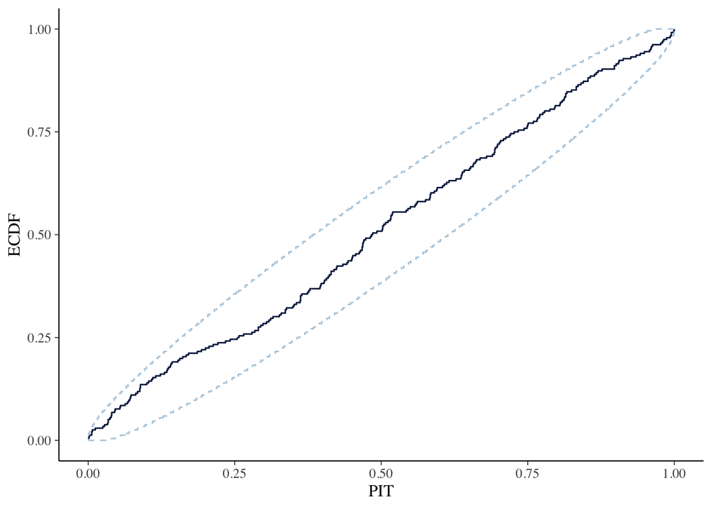

```r
ppc_pit_ecdf(y = epilepsy_standata$seizures,
                 poisson_gamma_fit$draws("ypred", format = "draws_matrix"))
```

Still looking good! But what’s the point?

### Random-Effects (Negative-Binomial)

Remember that we can represent the Poisson with a Gamma-distributed random effect as a Negative-Binomial parameterised by its mean and dispersion:

$$\int Poisson(y | \lambda\theta) \cdot Gamma(\theta | \phi, \phi) d\theta = NB(y|\lambda, \phi)$$

But don’t just take my word for it, let’s verify this in R by comparing the numerically integrated Poisson-Gamma with the Negative-Binomial:

```r
lambda <- 2.65
y <- 4
phi <- 1.5

poisson_gamma_pdf <- function(theta, y, lambda, phi) {
  exp(dpois(y, lambda * theta, log = TRUE) + dgamma(theta, shape = phi, rate = phi, log = TRUE))
}

integrate(poisson_gamma_pdf, 0, Inf, y, lambda, phi)
```

```
0.08891119 with absolute error < 9.4e-07
```

```r
dnbinom(y, mu = lambda, size = phi)
```

```
[1] 0.08891119
```

This means that we can express our random-effects model without needing to estimate the additional $N$ parameters! Let’s see that in Stan:

```stan
data {
  int N;
  int T;
  int K;
  array[N*T] int ID;
  matrix[N*T, K] x;
  array[N*T] int seizures;
}

parameters {
  real alpha;
  vector[K] beta;
  real<lower=0> u_shape;
}

transformed parameters {
  vector[N*T] lambda = alpha + x * beta;
}

model {
  alpha ~ normal(0, 5);
  beta ~ std_normal();
  u_shape ~ cauchy(0, 5);
  seizures ~ neg_binomial_2_log(lambda, u_shape);
}

generated quantities {
  array[N*T] int ypred = neg_binomial_2_log_rng(lambda, u_shape);
  vector[N*T] log_lik;
  for (nt in 1:(N*T)) {
    log_lik[nt] = neg_binomial_2_log_lpmf(seizures[nt] | lambda[nt], u_shape);
  }
}
```

```r
nb_fit <- nb_mod$sample(
  data = epilepsy_standata,
  parallel_chains = 4,
  refresh = 0,
  show_messages = FALSE,
  show_exceptions = FALSE,
  seed = 2024
)
```

```r
nb_fit$draws() |>
    mutate_variables(intercept = exp(alpha),
                     b_treat = exp(`beta[1]`),
                     b_visit = exp(`beta[2]`),
                     b_treat_x_visit = exp(`beta[3]`),
                     b_zAge = exp(`beta[4]`),
                     b_zBase = exp(`beta[5]`)) |>
    subset_draws(variable=c("intercept", "b_treat", "b_visit", "b_treat_x_visit", "b_zAge", "b_zBase")) |>
    summarise_draws()
```

```
# A tibble: 6 × 10
  variable         mean median     sd    mad    q5   q95  rhat ess_bulk ess_tail
  <chr>           <dbl>  <dbl>  <dbl>  <dbl> <dbl> <dbl> <dbl>    <dbl>    <dbl>
1 intercept       7.12   7.07  0.860  0.841  5.81   8.60  1.00    1838.    2267.
2 b_treat         0.852  0.842 0.142  0.136  0.639  1.11  1.00    1810.    2529.
3 b_visit         0.962  0.958 0.0620 0.0602 0.863  1.07  1.00    1875.    2485.
4 b_treat_x_visit 0.995  0.991 0.0902 0.0894 0.856  1.15  1.00    1794.    2597.
5 b_zAge          1.12   1.12  0.0578 0.0587 1.03   1.22  1.00    4286.    2915.
6 b_zBase         2.05   2.05  0.109  0.108  1.89   2.24  1.00    3723.    2878.
```

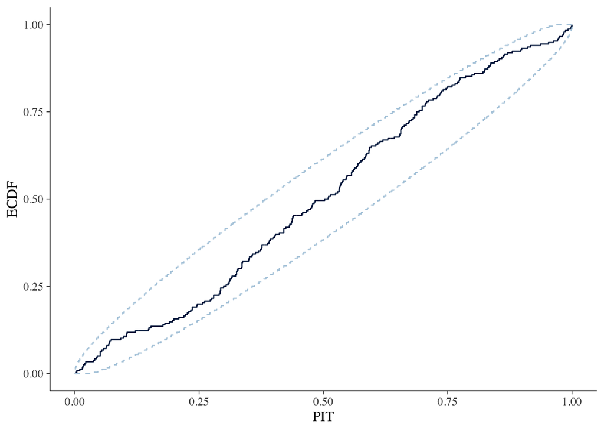

```r
ppc_pit_ecdf(y = epilepsy_standata$seizures,
                 nb_fit$draws("ypred", format = "draws_matrix"))
```

We can see that the estimates and PPC results are consistent with the previous random-effects (Gamma) model, but the ESS are much improved.

Could we do better if we were concerned about efficiency?

### Random-Effects (Negative-Binomial GLM)

```stan
data {
  int N;
  int T;
  int K;
  array[N*T] int ID;
  matrix[N*T, K] x;
  array[N*T] int seizures;
}

parameters {
  real alpha;
  vector[K] beta;
  real<lower=0> u_shape;
}

model {
  alpha ~ normal(0, 5);
  beta ~ std_normal();
  u_shape ~ cauchy(0, 5);
  seizures ~ neg_binomial_2_log_glm(x, alpha, beta, u_shape);
}

generated quantities {
  vector[N*T] lambda = alpha + x * beta;
  array[N*T] int ypred = neg_binomial_2_log_rng(lambda, u_shape);
  vector[N*T] log_lik;
  for (nt in 1:(N*T)) {
    log_lik[nt] = neg_binomial_2_log_lpmf(seizures[nt] | lambda[nt], u_shape);
  }
}
```

```r
nb_glm_fit <- nb_glm_mod$sample(
  data = epilepsy_standata,
  parallel_chains = 4,
  refresh = 0,
  show_messages = FALSE,
  show_exceptions = FALSE,
  seed = 2024
)
```

```r
nb_glm_fit$draws() |>
    mutate_variables(intercept = exp(alpha),
                     b_treat = exp(`beta[1]`),
                     b_visit = exp(`beta[2]`),
                     b_treat_x_visit = exp(`beta[3]`),
                     b_zAge = exp(`beta[4]`),
                     b_zBase = exp(`beta[5]`)) |>
    subset_draws(variable=c("intercept", "b_treat", "b_visit", "b_treat_x_visit", "b_zAge", "b_zBase")) |>
    summarise_draws()
```

```
# A tibble: 6 × 10
  variable         mean median     sd    mad    q5   q95  rhat ess_bulk ess_tail
  <chr>           <dbl>  <dbl>  <dbl>  <dbl> <dbl> <dbl> <dbl>    <dbl>    <dbl>
1 intercept       7.12   7.06  0.907  0.893  5.78   8.69  1.00    1523.    1865.
2 b_treat         0.853  0.838 0.151  0.147  0.627  1.12  1.00    1521.    2288.
3 b_visit         0.962  0.961 0.0641 0.0640 0.861  1.07  1.00    1576.    2134.
4 b_treat_x_visit 0.995  0.991 0.0936 0.0934 0.849  1.16  1.00    1630.    2401.
5 b_zAge          1.12   1.12  0.0589 0.0575 1.02   1.22  1.00    4173.    2959.
6 b_zBase         2.06   2.05  0.112  0.108  1.89   2.25  1.00    4037.    2695.
```

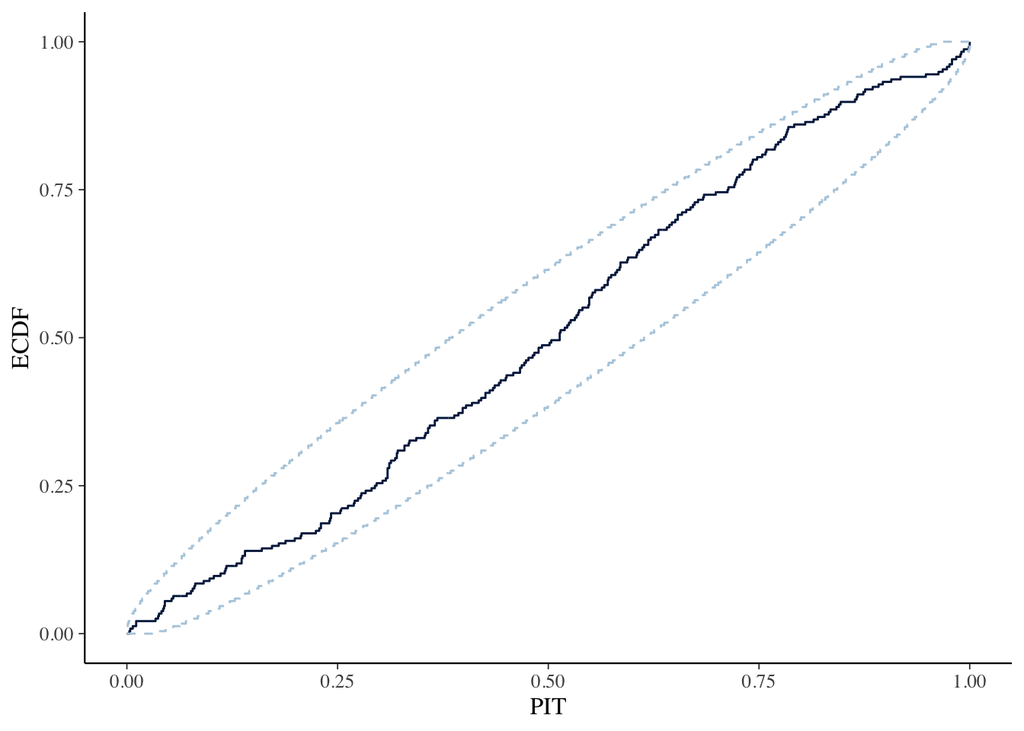

```r
ppc_pit_ecdf(y = epilepsy_standata$seizures,
                 nb_glm_fit$draws("ypred", format = "draws_matrix"))
```

We can see that the results are consistent, but now the GLM model is the fastest:

```r
poisson_ranef_fit$time()$total
```

```
[1] 1.12257
```

```r
poisson_gamma_fit$time()$total
```

```
[1] 1.441908
```

```r
nb_fit$time()$total
```

```
[1] 1.028801
```

```r
nb_glm_fit$time()$total
```

```
[1] 0.724715
```

### Selecting Models

Let’s investigate whether we want to keep our Random-Effects (Normal) or Random-Effects (Negative-Binomial) model.

#### Explanation

Do our inferences for the treatment effect differ between the two models?

```r
poisson_ranef_fit$draws() |>
    mutate_variables(b_treat = exp(`beta[1]`),
                     b_treat_x_visit = exp(`beta[3]`)) |>
    subset_draws(variable=c("b_treat", "b_treat_x_visit")) |>
    summarise_draws()
```

```
# A tibble: 2 × 10
  variable         mean median     sd    mad    q5   q95  rhat ess_bulk ess_tail
  <chr>           <dbl>  <dbl>  <dbl>  <dbl> <dbl> <dbl> <dbl>    <dbl>    <dbl>
1 b_treat         0.818  0.808 0.140  0.137  0.609  1.06  1.00     767.    1425.
2 b_treat_x_visit 0.970  0.970 0.0393 0.0394 0.907  1.03  1.00    2210.    2657.
```

```r
nb_fit$draws() |>
    mutate_variables(b_treat = exp(`beta[1]`),
                     b_treat_x_visit = exp(`beta[3]`)) |>
    subset_draws(variable=c("b_treat", "b_treat_x_visit")) |>
    summarise_draws()
```

```
# A tibble: 2 × 10
  variable         mean median     sd    mad    q5   q95  rhat ess_bulk ess_tail
  <chr>           <dbl>  <dbl>  <dbl>  <dbl> <dbl> <dbl> <dbl>    <dbl>    <dbl>
1 b_treat         0.852  0.842 0.142  0.136  0.639  1.11  1.00    1810.    2529.
2 b_treat_x_visit 0.995  0.991 0.0902 0.0894 0.856  1.15  1.00    1794.    2597.
```

If our goal was Explanation/Inference, we would likely select the Negative-Binomial.

#### Prediction

Can one of the models better predict new data than the other? We will use appromixate LOO-CV to investigate this.

```r
poisson_ranef_loo <- poisson_ranef_fit$loo()
poisson_ranef_loo
```

```
Computed from 4000 by 236 log-likelihood matrix.

         Estimate   SE
elpd_loo   -671.2 37.7
p_loo        97.5 15.3
looic      1342.4 75.4
------
MCSE of elpd_loo is NA.
MCSE and ESS estimates assume MCMC draws (r_eff in [0.5, 1.8]).

Pareto k diagnostic values:
                         Count Pct.    Min. ESS
(-Inf, 0.7]   (good)     226   95.8%   108
   (0.7, 1]   (bad)        7    3.0%   <NA>
   (1, Inf)   (very bad)   3    1.3%   <NA>
See help('pareto-k-diagnostic') for details.
```

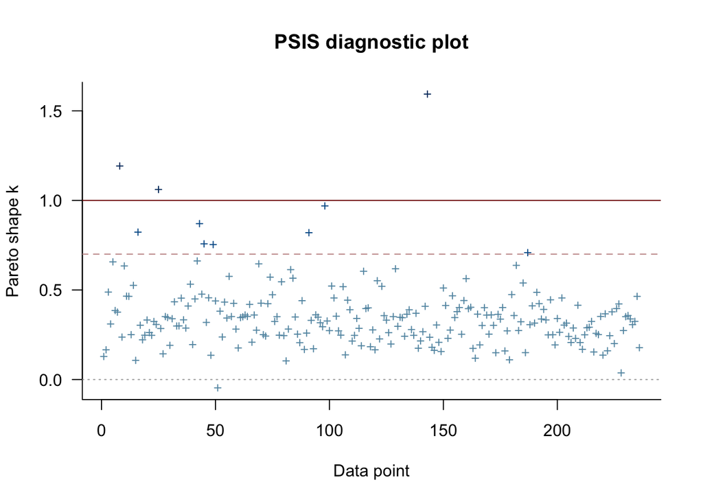

```r
plot(poisson_ranef_loo)
```

Looks like the PSIS algorithm is having difficulty approximating the leave-one-out performance any guesses why?

Let’s integrate the normal random effect out of our predictive density:

```stan
functions {
  real poisson_integrand(real u, real notused, array[] real theta,
               array[] real X_i, array[] int y_i) {
    real u_sd = theta[1];
    real lambda_minus_u = theta[2];
    real p = exp(normal_lpdf(u | 0, u_sd) + poisson_log_lpmf(y_i | u + lambda_minus_u));
    return (is_inf(p) || is_nan(p)) ? 0 : p;
  }
  real poisson_log_integrated_lpmf(int y, real lambda_minus_u, real u_sd) {
    real pmf =
      integrate_1d(poisson_integrand, negative_infinity(), positive_infinity(),
                   {u_sd, lambda_minus_u}, {0}, {y});

    return log(pmf);
  }
}

data {
  int N;
  int T;
  int K;
  array[N*T] int ID;
  matrix[N*T, K] x;
  array[N*T] int seizures;
}

parameters {
  real alpha;
  vector[K] beta;
  real<lower=0> u_sd;
  vector[N] u;
}

transformed parameters {
  vector[N*T] lambda = u[ID] + alpha + x * beta;
}

model {
  alpha ~ normal(0, 5);
  beta ~ std_normal();
  u_sd ~ cauchy(0, 5);
  u ~ normal(0, u_sd);
  seizures ~ poisson_log(lambda);
}

generated quantities {
  array[N*T] int ypred = poisson_log_rng(lambda);
  vector[N*T] log_lik;
  for (nt in 1:(N*T)) {
    log_lik[nt] = poisson_log_integrated_lpmf(seizures[nt] | (lambda - u[ID])[nt], u_sd);
  }
}
```

```r
poisson_ranef_int_fit <- poisson_ranef_int_mod$sample(
  data = epilepsy_standata,
  parallel_chains = 4,
  refresh = 0,
  show_messages = FALSE,
  show_exceptions = FALSE,
  seed = 2024
)
```

Let’s try our LOO results again:

```r
poisson_ranef_loo <- poisson_ranef_int_fit$loo()
poisson_ranef_loo
```

```
Computed from 4000 by 236 log-likelihood matrix.

         Estimate   SE
elpd_loo   -669.6 20.0
p_loo        17.0  2.6
looic      1339.2 40.0
------
MCSE of elpd_loo is NA.
MCSE and ESS estimates assume MCMC draws (r_eff in [0.2, 0.5]).

Pareto k diagnostic values:
                         Count Pct.    Min. ESS
(-Inf, 0.7]   (good)     235   99.6%   156
   (0.7, 1]   (bad)        1    0.4%   <NA>
   (1, Inf)   (very bad)   0    0.0%   <NA>
See help('pareto-k-diagnostic') for details.
```

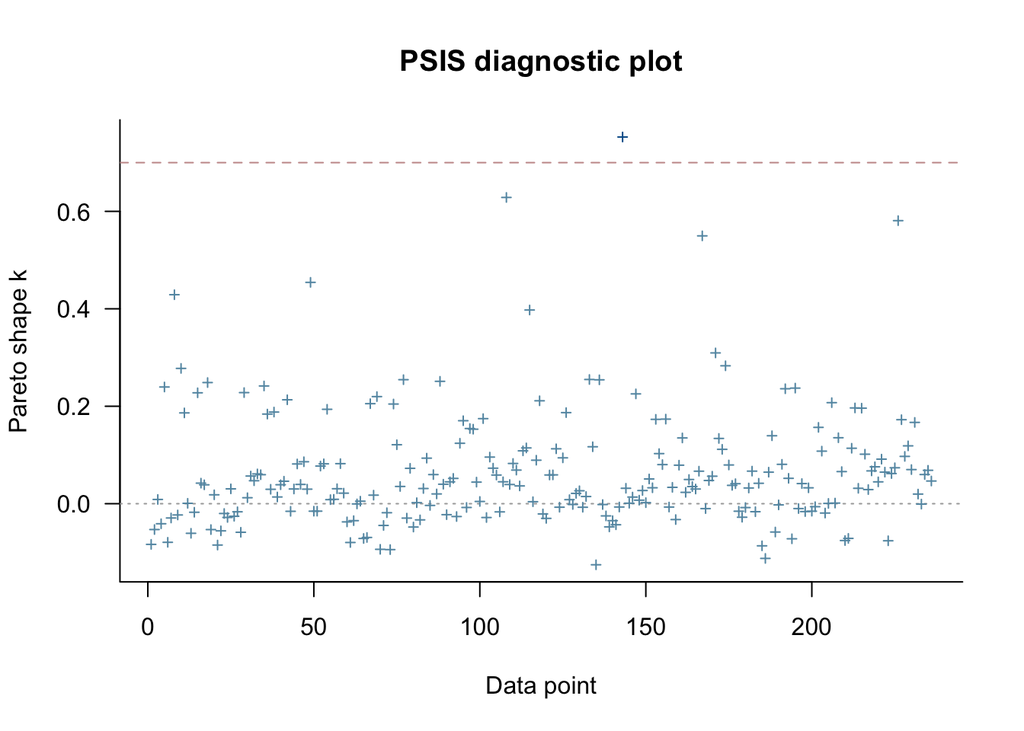

```r
plot(poisson_ranef_loo)
```

Even with integration, we still have a problematic data point. The next step is to try to use LOO with moment-matching to resolve this:

```r
poisson_ranef_loo <- poisson_ranef_int_fit$loo(moment_match = TRUE)
```

```
Compiling additional model methods...
```

```r
poisson_ranef_loo
```

```
Computed from 4000 by 236 log-likelihood matrix.

         Estimate   SE
elpd_loo   -669.6 20.0
p_loo        16.5  2.2
looic      1339.2 40.0
------
MCSE of elpd_loo is 0.2.
MCSE and ESS estimates assume MCMC draws (r_eff in [0.2, 0.5]).

All Pareto k estimates are good (k < 0.7).
See help('pareto-k-diagnostic') for details.
```

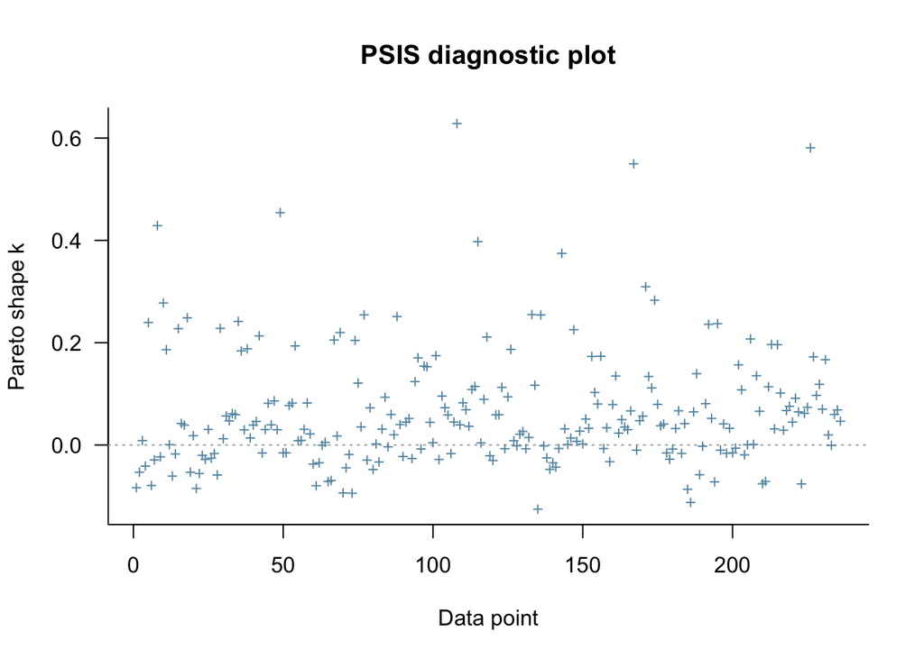

```r
plot(poisson_ranef_loo)
```

Much better! Now we can compare against our Negative-Binomial:

```r
nb_loo <- nb_fit$loo()
nb_loo
```

```
Computed from 4000 by 236 log-likelihood matrix.

         Estimate   SE
elpd_loo   -664.0 19.1
p_loo         7.7  1.6
looic      1328.1 38.2
------
MCSE of elpd_loo is 0.1.
MCSE and ESS estimates assume MCMC draws (r_eff in [0.5, 1.3]).

All Pareto k estimates are good (k < 0.7).
See help('pareto-k-diagnostic') for details.
```

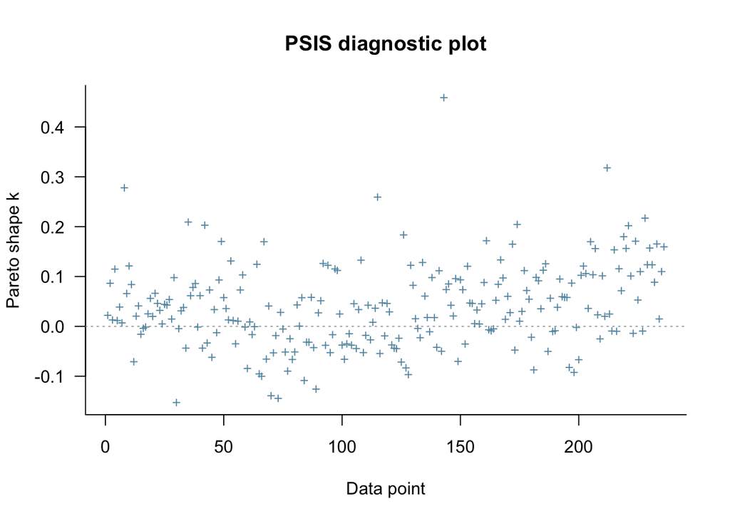

```r
plot(nb_loo)
```

```r
loo::loo_compare(list("Poisson" = poisson_ranef_loo, "Negative-Binomial" = nb_loo))
```

```
                  elpd_diff se_diff
Negative-Binomial  0.0       0.0
Poisson           -5.6       3.4
```

It looks like there is no meaningful difference in predictive performance between the two models. What should we do now?